# Домашнее задание по Эконометрике

### шаг первый: Загрузка данных из файла и Активация пакетов.

```r
library("checkpoint")
checkpoint("2015-04-22")
library("haven")
library("dplyr")
library("pander")
library("memisc")
library("psych")
library("ggplot2")
library("lmtest")
library("plm")
data <- read_sav("r22i_os25a.sav")
relevant_data <- data[,c("rj13.2","rh6","rh5","r_diplom","rj6.2","rm1","rm2")]
```

переменные, которые я выбрал: Индекс массы тела (BMI) и Среднее число еженедельных рабочих часов (rj6.2) .

Индекс массы тела я рассчитал используя вес и рост (rm1 , rm2) используя формулу $BMI = \frac{вес}{рост^2}$

Я выбрал эти переменные, так как считают, что они связаны с заработной платы среднего человека.

**Индекс массы тела**

- наивный прогноз: Люди, которые в хорошей физической форме, более продуктивны.
- реалистичный прогноз: Люди с более высокой заработной платой могут позволить себе лучшую еду в больших количествах.

думаю, что мы получим положительную корреляцию между заработной платой и Индексом массы тела

**Среднее число еженедельных рабочих часов**

- наивный прогноз: Люди, которые работают больше часов в неделю зарабатывать больше .
- реалистичный прогноз: Люди, которые получают большие зарплаты менее мотивированы работать сверхурочно

думаю, что мы получим отрицательную корреляцию между заработной платой и числом еженедельных рабочих часов

### шаг второй: Очистка и обработка данных.

```r
ves <- relevant_data$rm1
rost <- relevant_data$rm2 / 100
relevant_data <- mutate(relevant_data , bmi = ves / rost^2 )
relevant_data <- relevant_data[,-c(6,7)]



relevant_data <- relevant_data[relevant_data$bmi > 5 & relevant_data$bmi < 100 &  relevant_data$rj13.2 > 0 & relevant_data$rj6.2 < 168, ]
remove <- c(99999997,99999998,99999999)
relevant_data <- relevant_data[!relevant_data$rj13.2 %in% remove & !relevant_data$r_diplom %in% remove ,]
relevant_data$r_diplom <- factor(relevant_data$r_diplom)
levels(relevant_data$r_diplom) <- c(1,1,1,2,3,4)


relevant_data$rh5 <- factor(relevant_data$rh5)
levels(relevant_data$rh5) <- c("Male","Female")
relevant_data$rh6 <- 2013 -  relevant_data$rh6



colnames(relevant_data) <- c("Wages","Age","Sex","Education","Weekly_Working_Hours","BMI")
relevant_data$No_Education <- as.integer(relevant_data$Education == 1)
relevant_data$No_Education <- as.factor(relevant_data$No_Education)
relevant_data$Basic_education <- as.integer(relevant_data$Education == 2)
relevant_data$Basic_education <- as.factor(relevant_data$Basic_education)
relevant_data$Professional_education <- as.integer(relevant_data$Education == 3)
relevant_data$Professional_education <- as.factor(relevant_data$Professional_education)
relevant_data$Higher_education <- as.integer(relevant_data$Education == 4)
relevant_data$Higher_education <- as.factor(relevant_data$Higher_education)
```

### шаг третий:Таблица

```r
temp1 <- describe(relevant_data)[,4]
temp1 <-round(temp1 ,digits = 3)
temp1[1] <- paste("s.d.:",temp1[1],sep = "")
temp2 <- rbind(summary(relevant_data),temp1)
row.names(temp2) <- NULL
pandoc.table(temp2, split.table = Inf)
```

| Wages | Age | Sex | Education | Weekly_Working_Hours | BMI | No_Education | Basic_education | Professional_education | Higher_education |
| --- | --- | --- | --- | --- | --- | --- | --- | --- | --- |
| Min. : 50 | Min. :17.00 | Male :2500 | 1 : 468 | Min. : 3.00 | Min. :15.10 | 0 :5132 | 0 :3839 | 0 :4058 | 0 :3771 |
| 1st Qu.: 10000 | 1st Qu.:31.00 | Female:3100 | 2 :1761 | 1st Qu.: 40.00 | 1st Qu.:22.86 | 1 : 468 | 1 :1761 | 1 :1542 | 1 :1829 |
| Median : 16000 | Median :41.00 | NA’s :8984 | 3 :1542 | Median : 40.00 | Median :25.82 | NA’s:8984 | NA’s:8984 | NA’s:8984 | NA’s:8984 |
| Mean : 20049 | Mean :41.87 | NA | 4 :1829 | Mean : 42.97 | Mean :26.56 | NA | NA | NA | NA |
| 3rd Qu.: 25000 | 3rd Qu.:52.00 | NA | NA’s:8984 | 3rd Qu.: 48.00 | 3rd Qu.:29.41 | NA | NA | NA | NA |
| Max. :300000 | Max. :87.00 | NA | NA | Max. :136.00 | Max. :54.11 | NA | NA | NA | NA |
| NA’s :8984 | NA’s :8984 | NA | NA | NA’s :8984 | NA’s :8984 | NA | NA | NA | NA |
| s.d.:16028.58 | 12.634 | NA | NA | 12.03 | 5.15 | NA | NA | NA | NA |

*$\ast$ оригинальная переменныя Education из которой мы получили 4 фиктивных переменных была оставлина нарочно*

### шаг четвертый: Гистограммы дохода и возраста

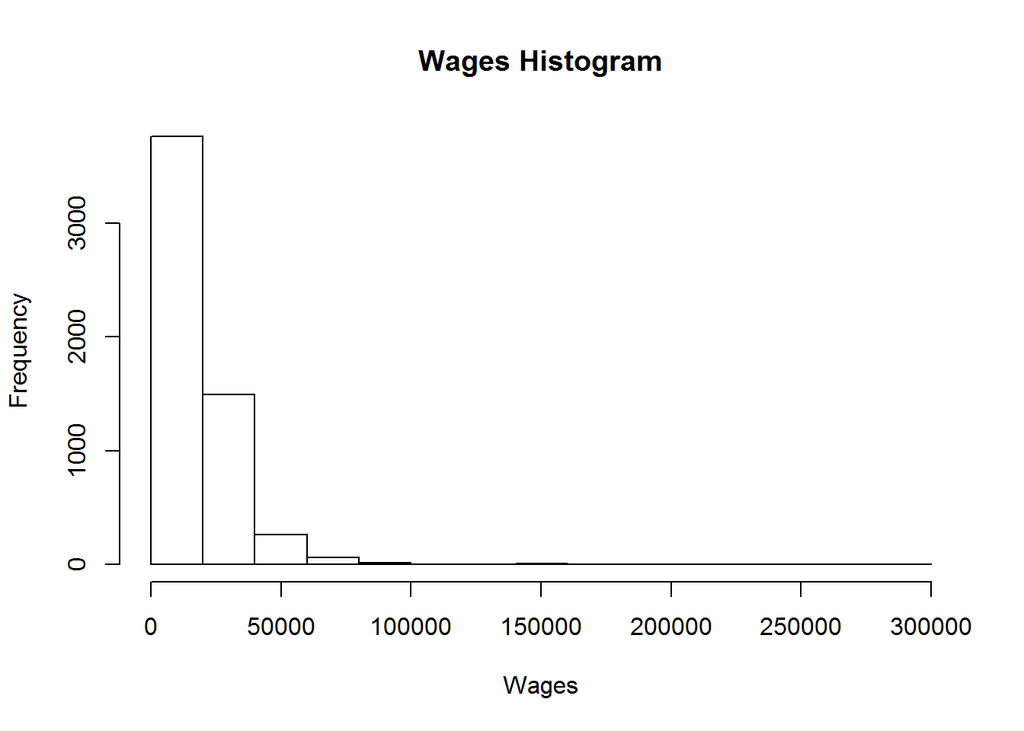

```r
hist(relevant_data$Wages,main = "Wages Histogram" , xlab = "Wages")
```

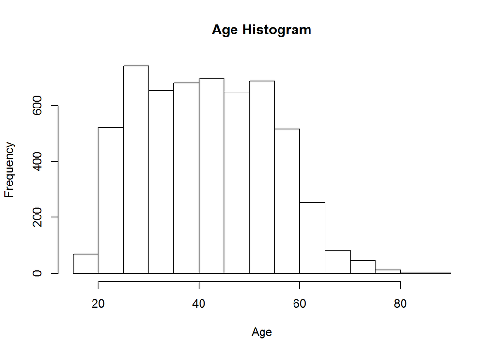

```r
hist(relevant_data$Age , main = "Age Histogram" , xlab = "Age")
```

### шаг пятый: простая линейная регрессия

```r
model1 <- lm(data = relevant_data,Wages~Age+Sex+Basic_education+Professional_education+Higher_education+BMI+Weekly_Working_Hours)
pandoc.table(coeftest(model1),split.table = Inf)
```

|  | Estimate | Std. Error | t value | Pr(>\|t\|) |
| --- | --- | --- | --- | --- |
| **(Intercept)** | 11865 | 1524 | 7.788 | 8.072e-15 |
| **Age** | -110.7 | 16.72 | -6.623 | 3.836e-11 |
| **SexFemale** | -7392 | 414.2 | -17.85 | 2.547e-69 |
| **Basic_education1** | 2941 | 776 | 3.79 | 0.000152 |
| **Professional_education1** | 5354 | 793.3 | 6.749 | 1.64e-11 |
| **Higher_education1** | 12890 | 780.7 | 16.51 | 7.727e-60 |
| **BMI** | 135.1 | 40.99 | 3.297 | 0.0009846 |
| **Weekly_Working_Hours** | 156.3 | 16.99 | 9.197 | 5.085e-20 |

Индекс массы тела и Среднее число еженедельных рабочих часов оказались **значимыми** на 5% уровне значимости. мой прогноз о влияние Среднего числа еженедельных рабочих часов оказался **ошибочным** (корреляция положительная)

**все переменные значимыми на 5% уровне значимости**

### шаг шестой: линейная регрессия с робастными ошибками

```r
pandoc.table(coeftest(model1,vcov. = vcovHC(model1)),split.table = Inf)
```

|  | Estimate | Std. Error | t value | Pr(>\|t\|) |
| --- | --- | --- | --- | --- |
| **(Intercept)** | 11865 | 1340 | 8.854 | 1.115e-18 |
| **Age** | -110.7 | 15.26 | -7.256 | 4.539e-13 |
| **SexFemale** | -7392 | 450.3 | -16.41 | 3.603e-59 |
| **Basic_education1** | 2941 | 505.3 | 5.82 | 6.193e-09 |
| **Professional_education1** | 5354 | 551 | 9.716 | 3.842e-22 |
| **Higher_education1** | 12890 | 638.6 | 20.18 | 1.68e-87 |
| **BMI** | 135.1 | 38.97 | 3.467 | 0.0005301 |
| **Weekly_Working_Hours** | 156.3 | 18.38 | 8.5 | 2.407e-17 |

никаких изменений в значимости переменных на 5% уровне значимости

**все переменные значимыми на 5% уровне значимости**

P.S. извините заранее за орфографические ошибоки. (я покинул Россию 20 лет назад)